# Intermediate and Advanced BigQuery for GA4

Lecture 2 — SQL Practice and Query Results

Author

Yushan Huang

Published

November 9, 2026

# 1 Introduction

This report documents ten SQL exercises from Lecture 2 using the public GA4 sample ecommerce dataset in Google BigQuery. Each section provides the SQL statement, a brief interpretation, and a screenshot of the actual query output. SQL blocks are shown for documentation only and are not executed by Quarto.

# 2 CTEs (WITH)

## 2.1 Query 1: Total Users and New Users

### 2.1.1 SQL Query

```sql
WITH UserInfo AS (
  SELECT
    user_pseudo_id,
    MAX(IF(event_name IN ('first_visit', 'first_open'), 1, 0)) AS is_new_user
  FROM `bigquery-public-data.ga4_obfuscated_sample_ecommerce.events_*`
  WHERE _TABLE_SUFFIX BETWEEN '20201101' AND '20201130'
  GROUP BY user_pseudo_id
)
SELECT
  COUNT(*) AS total_users,
  SUM(is_new_user) AS new_users
FROM UserInfo;
```

### 2.1.2 Explanation

The CTE creates one record per user and flags whether the user triggered a `first_visit` or `first_open` event in November 2020. The outer query counts all user records and sums the new-user flags. The output shows **79,421 total users** and **71,734 new users**. These figures describe users observed in the selected period; a new-user flag depends on the events present in that period.

### 2.1.3 BigQuery Output

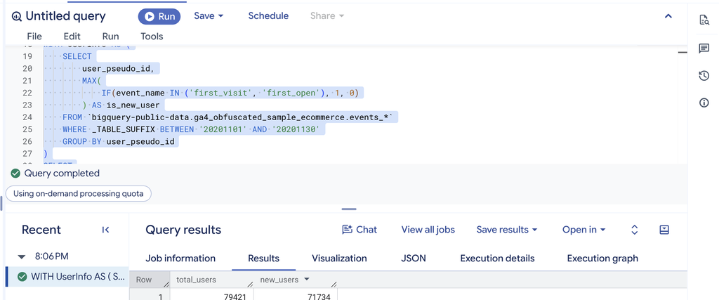

BigQuery result for Query 1: Total Users and New Users

# 3 Arrays and UNNEST

## 3.1 Query 2: Extract Page Location

### 3.1.1 SQL Query

```sql
SELECT
  TIMESTAMP_MICROS(event_timestamp) AS event_time,
  (
    SELECT value.string_value
    FROM UNNEST(event_params)
    WHERE key = 'page_location'
    LIMIT 1
  ) AS page_location
FROM `bigquery-public-data.ga4_obfuscated_sample_ecommerce.events_*`
WHERE event_name = 'page_view'
  AND _TABLE_SUFFIX BETWEEN '20201201' AND '20201202'
LIMIT 50;
```

### 3.1.2 Explanation

This query retrieves the timestamp and page URL for up to 50 `page_view` events on December 1–2, 2020. `TIMESTAMP_MICROS` converts the stored microsecond timestamp to a readable timestamp. The scalar subquery extracts `page_location` from the nested `event_params` array without multiplying the event rows. The output displays timestamps and Google Merchandise Store URLs.

### 3.1.3 BigQuery Output

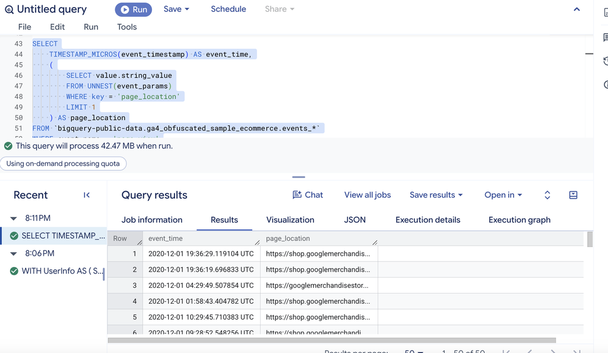

BigQuery result for Query 2: Extract Page Location

## 3.2 Query 3: Item-Level Purchase Analysis

### 3.2.1 SQL Query

```sql
SELECT
  event_date,
  item.item_name,
  COUNT(*) AS item_rows
FROM `bigquery-public-data.ga4_obfuscated_sample_ecommerce.events_*` AS e,
UNNEST(e.items) AS item
WHERE e.event_name = 'purchase'
  AND _TABLE_SUFFIX BETWEEN '20201201' AND '20201231'
GROUP BY event_date, item.item_name
ORDER BY item_rows DESC
LIMIT 20;
```

### 3.2.2 Explanation

This query expands the `items` array in purchase events into item-level rows. It groups by date and item name, counts how often each item appears, and returns the 20 date–item combinations with the highest counts. `item_rows` measures item records, not necessarily the number of units purchased.

### 3.2.3 BigQuery Output

[figure not shown]

BigQuery result for Query 3: Item-Level Purchase Analysis

# 4 STRING_AGG and ARRAY_AGG

## 4.1 Query 4: Event Types Observed Each Day

### 4.1.1 SQL Query

```sql
SELECT
  event_date,
  STRING_AGG(DISTINCT event_name, ', ' ORDER BY event_name) AS events_seen
FROM `bigquery-public-data.ga4_obfuscated_sample_ecommerce.events_*`
WHERE _TABLE_SUFFIX BETWEEN '20201201' AND '20201203'
GROUP BY event_date
ORDER BY event_date;
```

### 4.1.2 Explanation

This query groups events by date and combines distinct event names into one comma-separated, alphabetically ordered string per day. It helps identify which types of GA4 activity occurred on December 1–3, 2020. The output includes events such as `add_to_cart`, `page_view`, `purchase`, and `scroll`.

### 4.1.3 BigQuery Output

[figure not shown]

BigQuery result for Query 4: Event Types Observed Each Day

## 4.2 Query 5: Items Added to Cart by User

### 4.2.1 SQL Query

```sql
SELECT
  user_pseudo_id,
  ARRAY_AGG(item.item_name) AS items_added_to_cart
FROM `bigquery-public-data.ga4_obfuscated_sample_ecommerce.events_*`,
UNNEST(items) AS item
WHERE event_name = 'add_to_cart'
  AND _TABLE_SUFFIX BETWEEN '20201201' AND '20201231'
GROUP BY user_pseudo_id
ORDER BY user_pseudo_id
LIMIT 10;
```

### 4.2.2 Explanation

This query flattens item arrays from `add_to_cart` events and uses `ARRAY_AGG` to collect product names for each user. It returns 10 users sorted by pseudonymous ID. The screenshot shows multiple product names grouped under one user, illustrating how arrays preserve several values in a single result row.

### 4.2.3 BigQuery Output

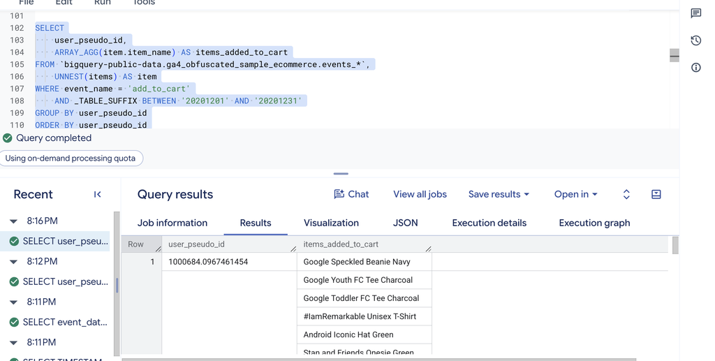

BigQuery result for Query 5: Items Added to Cart by User

## 4.3 Query 6: Session-Level Cart Summary

### 4.3.1 SQL Query

```sql
WITH add_to_cart AS (
  SELECT
    user_pseudo_id,
    (
      SELECT value.int_value
      FROM UNNEST(event_params)
      WHERE key = 'ga_session_id'
    ) AS session_id,
    TIMESTAMP_MICROS(event_timestamp) AS event_timestamp,
    i.item_id,
    i.item_name,
    i.quantity,
    i.price
  FROM `bigquery-public-data.ga4_obfuscated_sample_ecommerce.events_*`,
  UNNEST(items) AS i
  WHERE event_name = 'add_to_cart'
    AND _TABLE_SUFFIX BETWEEN '20210101' AND '20211231'
)
SELECT
  user_pseudo_id,
  session_id,
  COUNT(*) AS total_add_to_cart_events,
  ARRAY_AGG(
    STRUCT(item_id, item_name, quantity, price, event_timestamp)
    ORDER BY quantity DESC, event_timestamp ASC
    LIMIT 10
  ) AS cart_items
FROM add_to_cart
WHERE session_id IS NOT NULL
GROUP BY user_pseudo_id, session_id;
```

### 4.3.2 Explanation

The CTE extracts session IDs and item details from `add_to_cart` events. The final query groups the item-level records by user and session, counts the item rows, and builds an array of up to 10 item structures sorted by quantity and time. The result includes session IDs and nested product details. Because `UNNEST(items)` creates item-level records, `total_add_to_cart_events` is technically a count of item rows rather than necessarily distinct cart events.

### 4.3.3 BigQuery Output

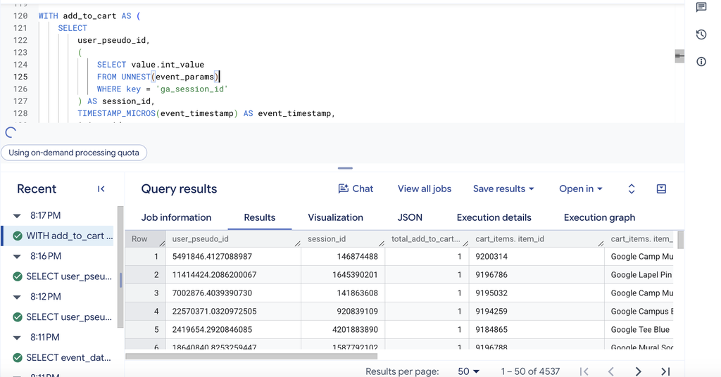

BigQuery result for Query 6: Session-Level Cart Summary

# 5 JOINs

## 5.1 Query 7: Daily Users, Purchases, and Conversion Rate

### 5.1.1 SQL Query

```sql
WITH daily_users AS (
  SELECT
    event_date,
    COUNT(DISTINCT user_pseudo_id) AS users
  FROM `bigquery-public-data.ga4_obfuscated_sample_ecommerce.events_*`
  WHERE _TABLE_SUFFIX BETWEEN '20201201' AND '20201231'
  GROUP BY event_date
),
daily_purchases AS (
  SELECT
    event_date,
    COUNT(DISTINCT (
      SELECT value.string_value
      FROM UNNEST(event_params)
      WHERE key = 'transaction_id'
    )) AS purchases
  FROM `bigquery-public-data.ga4_obfuscated_sample_ecommerce.events_*`
  WHERE event_name = 'purchase'
    AND _TABLE_SUFFIX BETWEEN '20201201' AND '20201231'
  GROUP BY event_date
)
SELECT
  u.event_date,
  u.users,
  IFNULL(p.purchases, 0) AS purchases,
  ROUND(IFNULL(p.purchases, 0) / NULLIF(u.users, 0) * 100, 2)
    AS conversion_rate_pct
FROM daily_users AS u
LEFT JOIN daily_purchases AS p
  ON u.event_date = p.event_date
ORDER BY u.event_date;
```

### 5.1.2 Explanation

Two CTEs calculate daily distinct users and daily distinct purchase transactions. A `LEFT JOIN` keeps all dates from the user table, while `IFNULL` replaces missing purchase counts with zero and `NULLIF` avoids division by zero. For December 1, the screenshot reports **4,308 users**, **96 purchases**, and a calculated rate of **2.23%**. The formula is transactions divided by users, so it is not exactly the percentage of users who purchased.

### 5.1.3 BigQuery Output

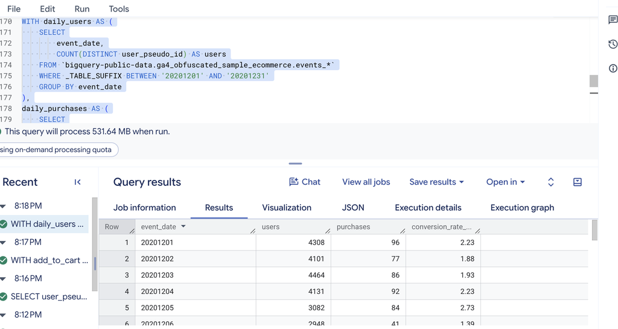

BigQuery result for Query 7: Daily Users, Purchases, and Conversion Rate

# 6 Window Functions and QUALIFY

## 6.1 Query 8: Top 3 Event Types per Day

### 6.1.1 SQL Query

```sql
WITH daily_event_counts AS (
  SELECT
    event_date,
    event_name,
    COUNT(*) AS events
  FROM `bigquery-public-data.ga4_obfuscated_sample_ecommerce.events_*`
  WHERE _TABLE_SUFFIX BETWEEN '20201201' AND '20201207'
  GROUP BY event_date, event_name
)
SELECT
  event_date,
  event_name,
  events,
  RANK() OVER (PARTITION BY event_date ORDER BY events DESC) AS rnk
FROM daily_event_counts
QUALIFY rnk <= 3
ORDER BY event_date, rnk;
```

### 6.1.2 Explanation

The CTE counts each event type per day. `RANK()` ranks event types within each date by frequency, and `QUALIFY` retains ranks 1 through 3. On December 1, the screenshot shows `page_view` (21,511), `user_engagement` (19,069), and `scroll` (8,629) as the leading event types. Ties could produce more than three rows for a date.

### 6.1.3 BigQuery Output

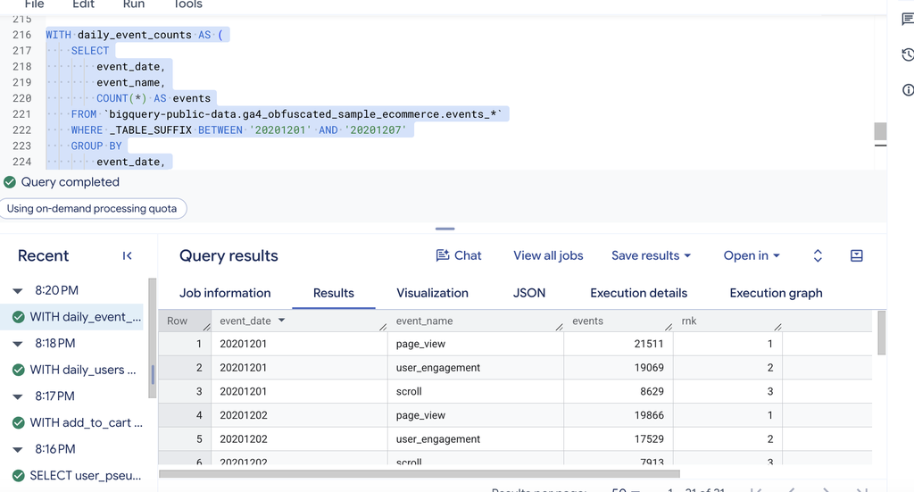

BigQuery result for Query 8: Top 3 Event Types per Day

## 6.2 Query 9: Rolling 7-Day Average of Purchases

### 6.2.1 SQL Query

```sql
WITH daily_purchases AS (
  SELECT
    PARSE_DATE('%Y%m%d', event_date) AS dt,
    COUNT(*) AS purchases
  FROM `bigquery-public-data.ga4_obfuscated_sample_ecommerce.events_*`
  WHERE event_name = 'purchase'
    AND _TABLE_SUFFIX BETWEEN '20201201' AND '20201231'
  GROUP BY dt
)
SELECT
  dt,
  purchases,
  AVG(purchases) OVER (
    ORDER BY dt
    ROWS BETWEEN 6 PRECEDING AND CURRENT ROW
  ) AS purchases_7d_avg
FROM daily_purchases
ORDER BY dt;
```

### 6.2.2 Explanation

The CTE counts purchase events by date. A window function averages the current row and up to six preceding rows to smooth daily variation. The screenshot shows **107 purchases** and a **107.0** average on December 1, followed by **82 purchases** and a **94.5** average on December 2. The first six averages use fewer than seven rows; dates with no purchase events would not appear unless a date calendar were added.

### 6.2.3 BigQuery Output

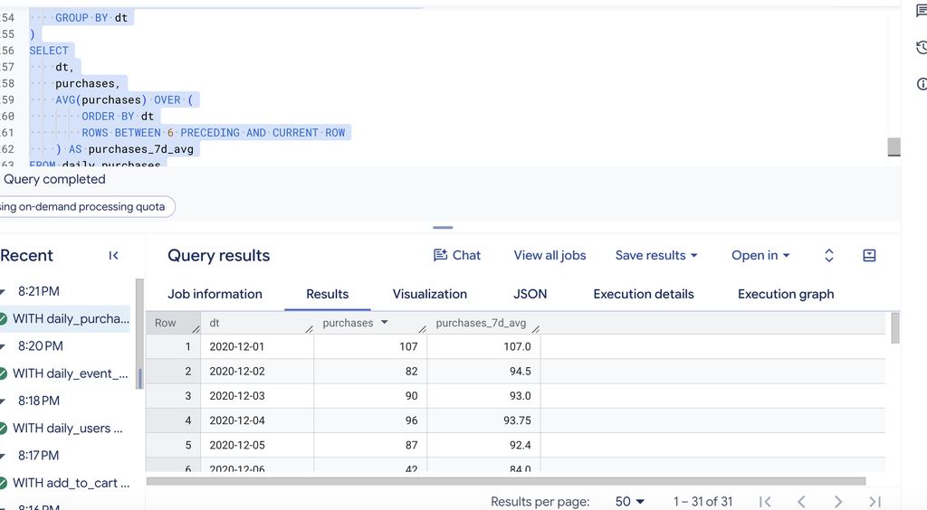

BigQuery result for Query 9: Rolling 7-Day Average of Purchases

# 7 Approximate Functions

## 7.1 Query 10: Approximate Distinct Users by Event Type

### 7.1.1 SQL Query

```sql
SELECT
  event_name,
  APPROX_COUNT_DISTINCT(user_pseudo_id) AS approx_users
FROM `bigquery-public-data.ga4_obfuscated_sample_ecommerce.events_*`
WHERE _TABLE_SUFFIX BETWEEN '20201201' AND '20201231'
GROUP BY event_name
ORDER BY approx_users DESC
LIMIT 15;
```

### 7.1.2 Explanation

This query estimates the number of unique users associated with each event type in December 2020 using `APPROX_COUNT_DISTINCT`. It orders the estimates from largest to smallest and returns the top 15 event types. The screenshot shows `page_view` (approximately 104,837 users), `session_start` (104,243), and `first_visit` (97,528) at the top. Approximate counts may differ slightly from exact distinct counts.

### 7.1.3 BigQuery Output

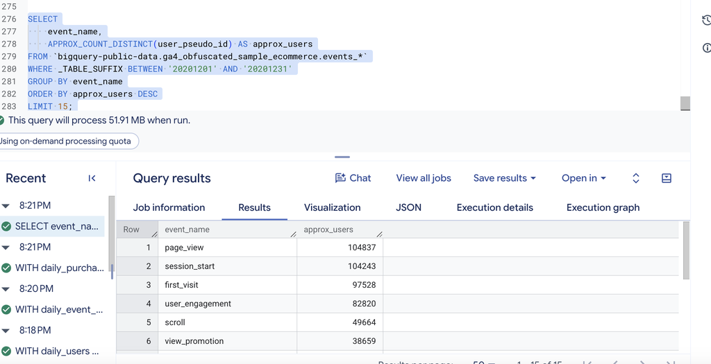

BigQuery result for Query 10: Approximate Distinct Users by Event Type

# 8 Conclusion

The exercises demonstrate how CTEs, nested arrays, aggregation, joins, window functions, and approximate distinct counting can be applied to GA4 event data. Query outputs should be interpreted according to their aggregation level, date range, and metric definitions.

# 9 Appendix